# Гипотезы да АБ-тесты: Что такое АБ-тест

Филипп

2018-05-31

## Agenda

- Что такое АБ-тест
- Подводные камни АБ-тестов
- Бутстрап, котики и печеньки

[figure not shown]

## Что такое АБ-тест

- Во всех сферах бизнеса требуется улучшать показатели
- Идеи улучшения могут быть разными
- Хотим понять какие из них работают
- Тестируем идеи на маленькой группе пользователей
- Проверяем гипотезу руботают ли, это и есть АБ-тест

## Пример

- Как думаете какая из рамок генерирует большую конверсию для веб-блога о дизайне?

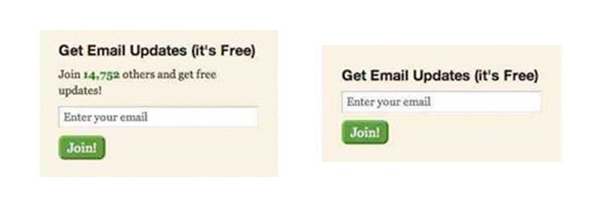

- Ещё примеры из веба [по ссылке](https://vc.ru/4374-ab-experts)

## Метрики

- Показатель для улучшения - метрика
- Метрика должна быть привязана к деньгам (выросли ли донаты, продажи)
- Часто денежные метрики грубые и слабо реагируют на изменения или нужно много времени чтобы их измерить
- Использование промежуточных метрик
- Сайт с арендой квартир: число посетителей за день, число уникальных посетителей и тп

## Где используют АБ-тесты

- Изменение дизайна на сайтах
- изменение функциональности в играх
- Работоспособность лекарств
- Выкатка алгоритма машинного обучения в прод
- Сбор налогов с помощью красивых деклараций

## Схема АБ-теста

- Фаза 1: планирование эксперимента, его дизайн
- Фаза 2: сбор статистики, проверка гипотез

[figure not shown]

## Кекс про кока-колу

- Как на продажи колы повлияет увеличение сахара?
- Фокус-группа пробует напитки
- С сахаром лучше, повышаем, продажи падают
- Что пошло не так

[figure not shown]

## Кекс про кока-колу (ответ)

Исследование проходило не в тех самых условиях, в которых люди обычно пьют кока-колу. Если речь идёт об одном маленьком стакане, то больше сахара правда нравится людям. Но если напиток употребляется постоянно в больших количествах, то больше сахара - хуже.

**Мораль:** тестирование идей должно происходить в максимально приближённых к реальности условиях.

## Другие подводные камни

> Что ещё может пойти не так?

## Подводные камни

- Любые изменения должны тестироваться в максимально приближённых к реальности условиях
- Хочется проверять много идей сразу, один и тот же пользователь не должен попадать в несколько тестовых групп
- Изменения могут взаимоуничтожать друг-друга
- Выборка пользователей должна быть репрезентативна
- Если выборка связная, может быть важен порядок предъявления изменений

## АА-тест

- Иногда, чтобы определить насколько хорошим вышел дизайн эксперимента, используют АА-тест
- Делим пользователей на две группы в соотеветствии с дизайном эксперимента
- Показываем обеим группам старый вариант
- Если гипотеза о том, что ничего не поменялось не отвергается, то круто, если она отвергается, мы что-то делаем не так

## О котах и печеньках

- мобильная игра “Cookie Cats”, стандартный match-three пазл, а ещё там есть поющие коты

[figure not shown]

## Ворота блокировщики

- По мере того, как игроки проходят уровни, они встречают ворота-блокеры, которые вынуждают их либо ждать длительное время, либо совершить внутриигровую покупку
- Вопрос - когда и где ставить эти ворота

[figure not shown]

## АБ-тест

- Изначально ворота стояли на 30 уровне, их переставили на 40
- Влияние этого изменения на retention (удержание игроков) - отношение уникальных пользователей, зашедших в игру на $N$-ый день после установки ко всем игрокам, усновившим приложение в этот день

[figure not shown]

## Данные для АБ-теста

- $90189$ наблюдений
- когда игрок устанавливает игру, он случайным образом относится либо к группе `gate_30` с воротами на 30-м уровне либо к группе `gate_40` с воротами на 40-м уровне.

```
##   userid version sum_gamerounds retention_1 retention_7
## 1    116 gate_30              3       FALSE       FALSE
## 2    337 gate_30             38        TRUE       FALSE
## 3    377 gate_40            165        TRUE       FALSE
## 4    483 gate_40              1       FALSE       FALSE
## 5    488 gate_40            179        TRUE        TRUE
```

## Распределение числа игровых сессий

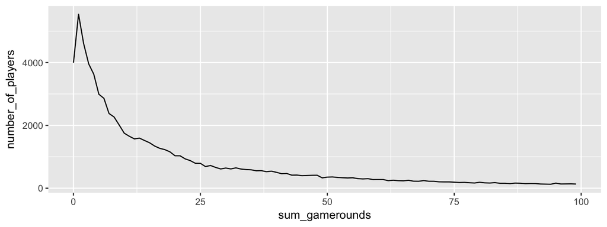

- Некоторые игроки установили игру, но даже ни разу не поиграли
- Многие закончили лишь пару сессий, некоторые сыграли более $80$ раз

## Удержание первого дня

Процент игроков, вернувшихся снова спустя день после установки:

```r
mean(df$retention_1)
```

```
## [1] 0.4452095
```

Удержание первого дня по группам:

```r
df %>% group_by(version) %>% summarise(mean(retention_1))
```

```
## # A tibble: 2 x 2
##   version `mean(retention_1)`
##   <fctr>                <dbl>
## 1 gate_30               0.448
## 2 gate_40               0.442
```

[figure not shown]

## Насколько велика разница?

- Похоже есть небольшое ухудшение в удержании при перносе ворот на 40 уровень
- Можно проверть это $z$-тестом для долей

```r
df_ex = df %>% group_by(version) %>% summarise(m = sum(retention_1),n = n())

test_res = prop.test(x = df_ex$m, n = df_ex$n, correct = FALSE)
test_res
```

```
##
##  2-sample test for equality of proportions without continuity
##  correction
##
## data:  df_ex$m out of df_ex$n
## X-squared = 3.183, df = 1, p-value = 0.07441
## alternative hypothesis: two.sided
## 95 percent confidence interval:
##  -0.0005820999  0.0123924394
## sample estimates:
##    prop 1    prop 2
## 0.4481879 0.4422827
```

## Бутстрапирование

- Можно проверить то же самое бустрапом
- Нас интересует распределение двух долей
- Будем делать выборки с возвратом, считать доли и запоминать их
- Получим распределение для наших долей

## Код для бустрапа

```r
iterations = 500 # число итераций
# В боевых условиях это обычно десятки тысяч итераций

# вектор для средних по воротам на 30 уровне
boot_1d_30 = rep(0, iterations)
# вектор для средних по воротам на 40 уровне
boot_1d_40 = rep(0, iterations)

for(i in 1:iterations){
    # генерируем таблицу с повторениями
    # соответствующую по размерам оригинальной
    boot_mean = sample_n(df, size = dim(df)[1], replace=TRUE) %>%
                 group_by(version) %>%
                 summarise(mean = mean(retention_1))

    # считаем средние и записываем их в вектора
    boot_1d_30[i] = boot_mean[1,2]$mean
    boot_1d_40[i] = boot_mean[2,2]$mean
}
```

## Распределение долей

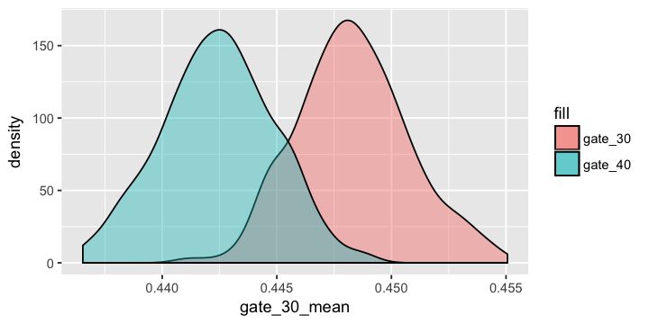

- Оценка распределений 1-day retention для ворот на разных уровнях
- Визуально есть какое-то доказательство разности групп, надо понять насколько они различны

## Распределение разности

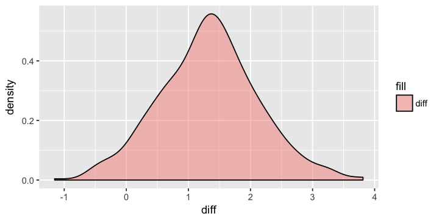

- Разница между группами составляет примерно $1\%$-$2\%$, большая часть распределения справа от нуля
- Вероятность того, что разница больше $0\%$ равна $0.956$
- Высокая вероятность того, что удержание первого дня выше в группе с воротам на $30$ уровне

## А что с 7 днями?

- удержание 7 дня по группам также немного ниже для ворот на $40$ уровне

```r
df %>% group_by(version) %>% summarise(mean(retention_7))
```

```
## # A tibble: 2 x 2
##   version `mean(retention_7)`
##   <fctr>                <dbl>
## 1 gate_30               0.190
## 2 gate_40               0.182
```

[figure not shown]

## Z-тест для 7 дней

- Можно проверть это $z$-тестом для долей

```r
df_ex = df %>% group_by(version) %>% summarise(m = sum(retention_7),n = n())

test_res = prop.test(x = df_ex$m, n = df_ex$n, correct = FALSE)
test_res
```

```
##
##  2-sample test for equality of proportions without continuity
##  correction
##
## data:  df_ex$m out of df_ex$n
## X-squared = 10.013, df = 1, p-value = 0.001554
## alternative hypothesis: two.sided
## 95 percent confidence interval:
##  0.003121044 0.013281552
## sample estimates:
##    prop 1    prop 2
## 0.1902013 0.1820000
```

## Бустрап для 7 дней

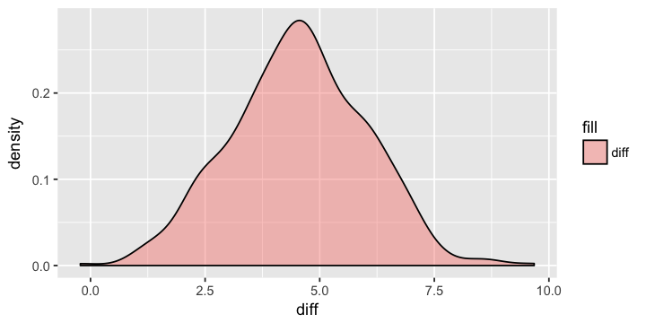

- Вероятность того, что разность больше нуля $0.998$

## Выводы

- Превышение 7-day retentio в группе с воротами на $30$ уровне над группой с вортами на $40$ уровне значимо
- Ежели хотим больше игроков, то оставляем ворота на $30$ уровне
- Давайте подумаем насколько существенен эффект от ворот на $30$ уровне

[figure not shown]

## Микра подъехала

Почему когда ворота раньше ретеншн выше? Логично было бы обратное - чем позже ставится препятствие, тем дольше игроки взаимодействуют с игрой.

На самом деле нет. Теория геденетстической адаптации может помочь с объяснением. Геденестическая адаптация - тенденция получать всэ мнеьше удовольствия от деятельности, если она продолжается длительное время.

Заставляя игроков сделать паузу, мы продлеваем их удовольствие и они хотят вернуться. Отодвигая ворота, мы даём игрокам наиграться и заскучать.